# US COVID-19 Prediction

David Jackson

12/05/2020

## GGPLOt2 Plots of Daily Deaths and Cases

#### Source: John Hopkin’s Uni CSSE

#### Average US Covid-19 Deaths/day

```
## [1] 996.1857
```

```
## [1] 278932
```

### Washington University

#### Institute for Health Metrics and Evaluation

- "Daily deaths is the best indicator of the progression of the pandemic, although there is generally a 17-21 day lag between infection and deaths.
- Revised US COVID19 Deaths: 300,000 by Dec. 1, 2021 (Updated Aug. 6, 2020)
- Revised US COVID19 Deaths: 410,000 by Jan. 1, 2021 (Updated Sept. 5, 2020)
- Revised US COVID19 Deaths: 363,269 by Jan. 1, 2021 (Updated Oct. 2, 2020)
- Revised US COVID19 Deaths: 363,269 by Feb. 1, 2021 (Updated Oct. 9, 2020)
- Revised US COVID19 Deaths: 394,693 by Feb. 1, 2021 (Updated Oct. 10, 2020)
- Revised US COVID19 Deaths: 389,087 by Feb. 1, 2021 (Updated Oct. 15,2020)
- Revised US COVID19 Deaths: 385,611 by Feb. 1, 2021 (Updated Oct. 22, 2020)
- Revised US COVID19 Deaths: 399,163 by Feb. 1, 2021 (Updated Oct. 29, 2020)
- Revised US COVID19 Deaths: 399,163 by Feb. 1, 2021 (Updated Nov. 07, 2020)
- Revised US COVID19 Deaths: 438,941 by Mar. 1, 2021 (Updated Nov. 14, 2020)
- Revised US COVID19 Deaths: 470,974 by Mar. 1, 2021 (Updated Nov. 19, 2020)
- Revised US COVID19 Deaths: 538,893 by Apr. 1, 2021 (Updated Dec. 03, 2020)

#### US COVID-19 Deaths Guesstimate as of Oct. 17, 2020

- Oct. 17, 2020 Fixed math error for average US Deaths per day
- Dec. 15,2020 WU IHME Model.
- My Projections = +/- 5%
- Nov 1, 2020 = 233,706 : Actual: 229,672
- Dec.1, 2020 = 261,895 : Range: 248800 - 274989
- Jan.1, 2021 = 291151 : Range: 276593 - 305708
- Feb.1, 2020 = 317,482 : Range: 301607 - 333356
- Mar, 1 2021 = 319,528 (Nov. 14, 2020)
- Apr. 1, 2020 = 396,154 (Dec. 3, 2020)

### US COVID19 Projected Deaths

#### Just COVID19 Deaths for Jan. 1, 2021: 363,269

```
## [1] 3243.731
```

```
## [1] 304832.8
```

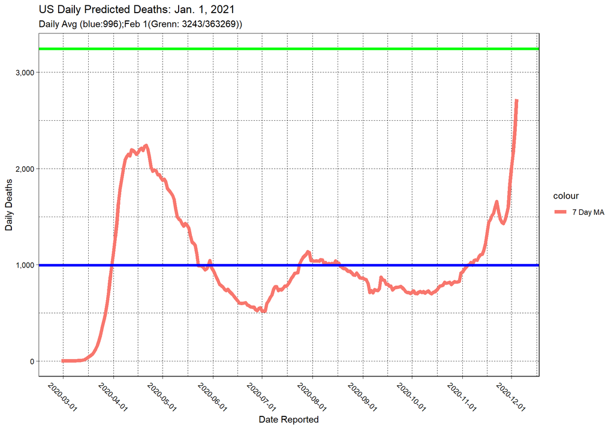

```
## [1] 2037.814
```

```
## [1] 337707
```

#### Just COVID19 Deaths for Feb. 1, 2021

[figure not shown]

#### US COVID-19 Deaths by Mar. 1, 2021

```
## [1] 1839.184
```

```
## [1] 365600.2
```

[figure not shown]

#### US COVID19 Projected Deaths for Apr. 1, 2021

```
## [1] 2203.059
```

```
## [1] 396481.9
```

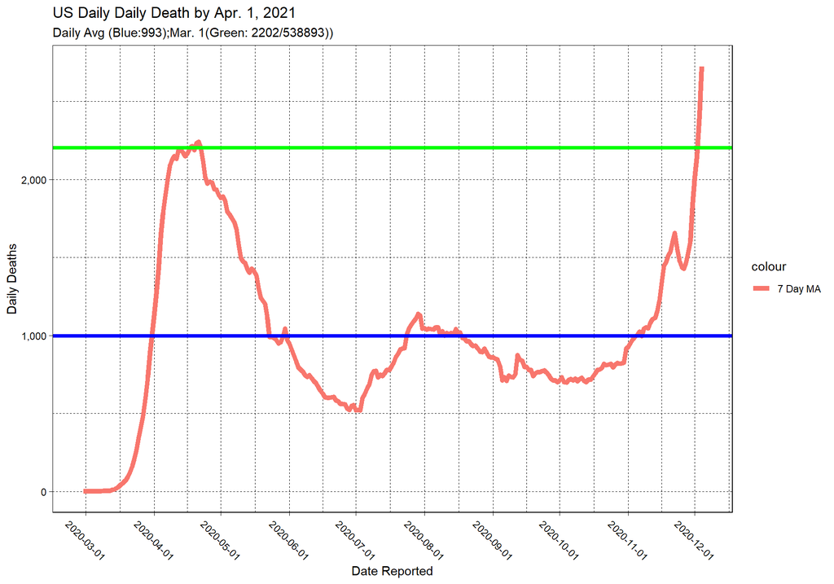